# Risk Factor Analysis

## Outcome Variable

**Outcome Variable:** y_rate_haz

## Predictor Variables

**Intervention Variable:** parity

**Adjustment Set:**

unadjusted

## Stratifying Variables

The analysis was stratified on these variable(s):

- agecat
- studyid
- country

## Data Summary

| agecat | studyid | country | parity | n_cell | n |
| --- | --- | --- | --- | --- | --- |
| 0-3 months | ki1000304b-SAS-CompFeed | INDIA | 1 | 105 | 389 |
| 0-3 months | ki1000304b-SAS-CompFeed | INDIA | 2 | 95 | 389 |
| 0-3 months | ki1000304b-SAS-CompFeed | INDIA | 3+ | 189 | 389 |
| 0-3 months | ki1017093b-PROVIDE | BANGLADESH | 1 | 242 | 640 |
| 0-3 months | ki1017093b-PROVIDE | BANGLADESH | 2 | 226 | 640 |
| 0-3 months | ki1017093b-PROVIDE | BANGLADESH | 3+ | 172 | 640 |
| 0-3 months | ki1101329-Keneba | GAMBIA | 1 | 130 | 1145 |
| 0-3 months | ki1101329-Keneba | GAMBIA | 2 | 113 | 1145 |
| 0-3 months | ki1101329-Keneba | GAMBIA | 3+ | 902 | 1145 |
| 0-3 months | ki1113344-GMS-Nepal | NEPAL | 1 | 137 | 509 |
| 0-3 months | ki1113344-GMS-Nepal | NEPAL | 2 | 129 | 509 |
| 0-3 months | ki1113344-GMS-Nepal | NEPAL | 3+ | 243 | 509 |
| 0-3 months | ki1126311-ZVITAMBO | ZIMBABWE | 1 | 3100 | 7981 |
| 0-3 months | ki1126311-ZVITAMBO | ZIMBABWE | 2 | 2478 | 7981 |
| 0-3 months | ki1126311-ZVITAMBO | ZIMBABWE | 3+ | 2403 | 7981 |
| 0-3 months | ki1135781-COHORTS | GUATEMALA | 1 | 48 | 356 |
| 0-3 months | ki1135781-COHORTS | GUATEMALA | 2 | 63 | 356 |
| 0-3 months | ki1135781-COHORTS | GUATEMALA | 3+ | 245 | 356 |
| 0-3 months | ki1135781-COHORTS | INDIA | 1 | 671 | 4021 |
| 0-3 months | ki1135781-COHORTS | INDIA | 2 | 1015 | 4021 |
| 0-3 months | ki1135781-COHORTS | INDIA | 3+ | 2335 | 4021 |
| 0-3 months | kiGH5241-JiVitA-3 | BANGLADESH | 1 | 3164 | 9826 |
| 0-3 months | kiGH5241-JiVitA-3 | BANGLADESH | 2 | 3408 | 9826 |
| 0-3 months | kiGH5241-JiVitA-3 | BANGLADESH | 3+ | 3254 | 9826 |
| 3-6 months | ki1000304b-SAS-CompFeed | INDIA | 1 | 93 | 349 |
| 3-6 months | ki1000304b-SAS-CompFeed | INDIA | 2 | 82 | 349 |
| 3-6 months | ki1000304b-SAS-CompFeed | INDIA | 3+ | 174 | 349 |
| 3-6 months | ki1017093b-PROVIDE | BANGLADESH | 1 | 214 | 598 |
| 3-6 months | ki1017093b-PROVIDE | BANGLADESH | 2 | 221 | 598 |
| 3-6 months | ki1017093b-PROVIDE | BANGLADESH | 3+ | 163 | 598 |

[output cut: 156 more lines]

The following strata were considered:

- agecat: 0-3 months, studyid: ki1000304b-SAS-CompFeed, country: INDIA
- agecat: 0-3 months, studyid: ki1017093b-PROVIDE, country: BANGLADESH
- agecat: 0-3 months, studyid: ki1101329-Keneba, country: GAMBIA
- agecat: 0-3 months, studyid: ki1113344-GMS-Nepal, country: NEPAL
- agecat: 0-3 months, studyid: ki1126311-ZVITAMBO, country: ZIMBABWE
- agecat: 0-3 months, studyid: ki1135781-COHORTS, country: GUATEMALA
- agecat: 0-3 months, studyid: ki1135781-COHORTS, country: INDIA
- agecat: 0-3 months, studyid: kiGH5241-JiVitA-3, country: BANGLADESH
- agecat: 12-15 months, studyid: ki1000304b-SAS-CompFeed, country: INDIA
- agecat: 12-15 months, studyid: ki1000304b-SAS-FoodSuppl, country: INDIA
- agecat: 12-15 months, studyid: ki1017093b-PROVIDE, country: BANGLADESH
- agecat: 12-15 months, studyid: ki1066203-TanzaniaChild2, country: TANZANIA, UNITED REPUBLIC OF
- agecat: 12-15 months, studyid: ki1101329-Keneba, country: GAMBIA
- agecat: 12-15 months, studyid: ki1113344-GMS-Nepal, country: NEPAL
- agecat: 12-15 months, studyid: ki1126311-ZVITAMBO, country: ZIMBABWE
- agecat: 12-15 months, studyid: ki1135781-COHORTS, country: GUATEMALA
- agecat: 15-18 months, studyid: ki1000304b-SAS-CompFeed, country: INDIA
- agecat: 15-18 months, studyid: ki1000304b-SAS-FoodSuppl, country: INDIA
- agecat: 15-18 months, studyid: ki1017093b-PROVIDE, country: BANGLADESH
- agecat: 15-18 months, studyid: ki1066203-TanzaniaChild2, country: TANZANIA, UNITED REPUBLIC OF
- agecat: 15-18 months, studyid: ki1101329-Keneba, country: GAMBIA
- agecat: 15-18 months, studyid: ki1113344-GMS-Nepal, country: NEPAL
- agecat: 15-18 months, studyid: ki1126311-ZVITAMBO, country: ZIMBABWE
- agecat: 15-18 months, studyid: ki1135781-COHORTS, country: GUATEMALA
- agecat: 18-21 months, studyid: ki1017093b-PROVIDE, country: BANGLADESH
- agecat: 18-21 months, studyid: ki1066203-TanzaniaChild2, country: TANZANIA, UNITED REPUBLIC OF
- agecat: 18-21 months, studyid: ki1101329-Keneba, country: GAMBIA
- agecat: 18-21 months, studyid: ki1113344-GMS-Nepal, country: NEPAL
- agecat: 18-21 months, studyid: ki1126311-ZVITAMBO, country: ZIMBABWE
- agecat: 18-21 months, studyid: ki1135781-COHORTS, country: GUATEMALA
- agecat: 21-24 months, studyid: ki1017093b-PROVIDE, country: BANGLADESH
- agecat: 21-24 months, studyid: ki1101329-Keneba, country: GAMBIA
- agecat: 21-24 months, studyid: ki1113344-GMS-Nepal, country: NEPAL
- agecat: 21-24 months, studyid: ki1126311-ZVITAMBO, country: ZIMBABWE
- agecat: 21-24 months, studyid: ki1135781-COHORTS, country: GUATEMALA
- agecat: 3-6 months, studyid: ki1000304b-SAS-CompFeed, country: INDIA
- agecat: 3-6 months, studyid: ki1017093b-PROVIDE, country: BANGLADESH
- agecat: 3-6 months, studyid: ki1066203-TanzaniaChild2, country: TANZANIA, UNITED REPUBLIC OF
- agecat: 3-6 months, studyid: ki1101329-Keneba, country: GAMBIA
- agecat: 3-6 months, studyid: ki1113344-GMS-Nepal, country: NEPAL
- agecat: 3-6 months, studyid: ki1126311-ZVITAMBO, country: ZIMBABWE
- agecat: 3-6 months, studyid: ki1135781-COHORTS, country: GUATEMALA
- agecat: 3-6 months, studyid: ki1135781-COHORTS, country: INDIA
- agecat: 3-6 months, studyid: kiGH5241-JiVitA-3, country: BANGLADESH
- agecat: 6-9 months, studyid: ki1000304b-SAS-CompFeed, country: INDIA
- agecat: 6-9 months, studyid: ki1000304b-SAS-FoodSuppl, country: INDIA
- agecat: 6-9 months, studyid: ki1017093b-PROVIDE, country: BANGLADESH
- agecat: 6-9 months, studyid: ki1066203-TanzaniaChild2, country: TANZANIA, UNITED REPUBLIC OF
- agecat: 6-9 months, studyid: ki1101329-Keneba, country: GAMBIA
- agecat: 6-9 months, studyid: ki1113344-GMS-Nepal, country: NEPAL
- agecat: 6-9 months, studyid: ki1126311-ZVITAMBO, country: ZIMBABWE
- agecat: 6-9 months, studyid: ki1135781-COHORTS, country: GUATEMALA
- agecat: 6-9 months, studyid: ki1135781-COHORTS, country: INDIA
- agecat: 9-12 months, studyid: ki1000304b-SAS-CompFeed, country: INDIA
- agecat: 9-12 months, studyid: ki1000304b-SAS-FoodSuppl, country: INDIA
- agecat: 9-12 months, studyid: ki1017093b-PROVIDE, country: BANGLADESH
- agecat: 9-12 months, studyid: ki1066203-TanzaniaChild2, country: TANZANIA, UNITED REPUBLIC OF
- agecat: 9-12 months, studyid: ki1101329-Keneba, country: GAMBIA
- agecat: 9-12 months, studyid: ki1113344-GMS-Nepal, country: NEPAL
- agecat: 9-12 months, studyid: ki1126311-ZVITAMBO, country: ZIMBABWE
- agecat: 9-12 months, studyid: ki1135781-COHORTS, country: GUATEMALA
- agecat: 9-12 months, studyid: ki1135781-COHORTS, country: INDIA

### Dropped Strata

Some strata were dropped due to rare outcomes:

- agecat: 6-9 months, studyid: ki1000304b-SAS-FoodSuppl, country: INDIA
- agecat: 9-12 months, studyid: ki1000304b-SAS-FoodSuppl, country: INDIA
- agecat: 12-15 months, studyid: ki1000304b-SAS-FoodSuppl, country: INDIA
- agecat: 15-18 months, studyid: ki1000304b-SAS-FoodSuppl, country: INDIA
- agecat: 18-21 months, studyid: ki1066203-TanzaniaChild2, country: TANZANIA, UNITED REPUBLIC OF

## Methods Detail

We’re interested in the causal parameters $E[Y_a]$ for all values of $a \in \mathcal{A}$. These parameters represent the mean outcome if, possibly contrary to fact, we intervened to set all units to have $A=a$. Under the randomization and positivity assumptions, these are identified by the statistical parameters $\psi_a=E_W[E_{Y|A,W}(Y|A=a,W)]$. In addition, we’re interested in the mean of $Y$, $E[Y]$ under no intervention (the observed mean). We will estimate these parameters by using SuperLearner to fit the relevant likelihood factors – $E_{Y|A,W}(Y|A=a,W)$ and $p(A=a|W)$, and then updating our likelihood fit using a joint TMLE.

For unadjusted analyses ($W=\{\}$), initial likelihoods were estimated using Lrnr_glm to estimate the simple $E(Y|A)$ and Lrnr_mean to estimate $p(A)$. For adjusted analyses, a small library containing Lrnr_glmnet, Lrnr_xgboost, and Lrnr_mean was used.

Having estimated these parameters, we will then use the delta method to estimate relative risks and attributable risks relative to a prespecified baseline level of $A$.

# Results Detail

## Results Plots

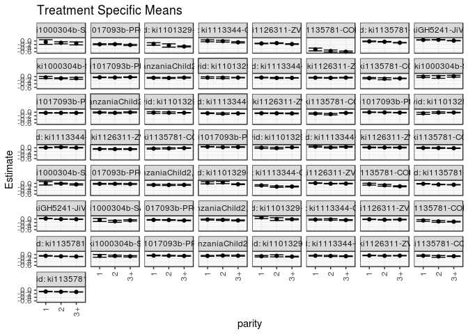

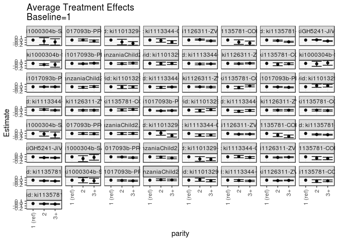

[figure not shown]

## Results Table

### Parameter: TSM

| agecat | studyid | country | intervention_level | baseline_level | estimate | ci_lower | ci_upper |
| --- | --- | --- | --- | --- | --- | --- | --- |
| 0-3 months | ki1000304b-SAS-CompFeed | INDIA | 1 | NA | -0.0537879 | -0.1836082 | 0.0760324 |
| 0-3 months | ki1000304b-SAS-CompFeed | INDIA | 2 | NA | -0.0985671 | -0.1556905 | -0.0414437 |
| 0-3 months | ki1000304b-SAS-CompFeed | INDIA | 3+ | NA | -0.1328419 | -0.2147850 | -0.0508989 |
| 0-3 months | ki1017093b-PROVIDE | BANGLADESH | 1 | NA | -0.1793779 | -0.2082979 | -0.1504580 |
| 0-3 months | ki1017093b-PROVIDE | BANGLADESH | 2 | NA | -0.1739360 | -0.2027779 | -0.1450941 |
| 0-3 months | ki1017093b-PROVIDE | BANGLADESH | 3+ | NA | -0.2187601 | -0.2512693 | -0.1862508 |
| 0-3 months | ki1101329-Keneba | GAMBIA | 1 | NA | -0.1645456 | -0.2349040 | -0.0941872 |
| 0-3 months | ki1101329-Keneba | GAMBIA | 2 | NA | -0.2476390 | -0.3395852 | -0.1556929 |
| 0-3 months | ki1101329-Keneba | GAMBIA | 3+ | NA | -0.3033631 | -0.3312523 | -0.2754739 |
| 0-3 months | ki1113344-GMS-Nepal | NEPAL | 1 | NA | 0.0129675 | -0.0380334 | 0.0639683 |
| 0-3 months | ki1113344-GMS-Nepal | NEPAL | 2 | NA | -0.0063699 | -0.0577080 | 0.0449682 |
| 0-3 months | ki1113344-GMS-Nepal | NEPAL | 3+ | NA | -0.0704722 | -0.1046181 | -0.0363263 |
| 0-3 months | ki1126311-ZVITAMBO | ZIMBABWE | 1 | NA | -0.1360342 | -0.1525538 | -0.1195146 |
| 0-3 months | ki1126311-ZVITAMBO | ZIMBABWE | 2 | NA | -0.1179753 | -0.1358640 | -0.1000867 |
| 0-3 months | ki1126311-ZVITAMBO | ZIMBABWE | 3+ | NA | -0.1687210 | -0.1876347 | -0.1498072 |
| 0-3 months | ki1135781-COHORTS | GUATEMALA | 1 | NA | -0.4707540 | -0.5476490 | -0.3938589 |
| 0-3 months | ki1135781-COHORTS | GUATEMALA | 2 | NA | -0.5577356 | -0.6142063 | -0.5012648 |
| 0-3 months | ki1135781-COHORTS | GUATEMALA | 3+ | NA | -0.5994530 | -0.6397319 | -0.5591740 |
| 0-3 months | ki1135781-COHORTS | INDIA | 1 | NA | -0.0187050 | -0.0384547 | 0.0010446 |
| 0-3 months | ki1135781-COHORTS | INDIA | 2 | NA | -0.0416906 | -0.0579024 | -0.0254789 |
| 0-3 months | ki1135781-COHORTS | INDIA | 3+ | NA | -0.0931318 | -0.1052278 | -0.0810358 |
| 0-3 months | kiGH5241-JiVitA-3 | BANGLADESH | 1 | NA | 0.0640334 | 0.0525656 | 0.0755013 |
| 0-3 months | kiGH5241-JiVitA-3 | BANGLADESH | 2 | NA | 0.0717214 | 0.0606511 | 0.0827917 |
| 0-3 months | kiGH5241-JiVitA-3 | BANGLADESH | 3+ | NA | 0.0233674 | 0.0121476 | 0.0345872 |
| 3-6 months | ki1000304b-SAS-CompFeed | INDIA | 1 | NA | 0.0050629 | -0.0896703 | 0.0997962 |
| 3-6 months | ki1000304b-SAS-CompFeed | INDIA | 2 | NA | -0.0115467 | -0.0379216 | 0.0148281 |
| 3-6 months | ki1000304b-SAS-CompFeed | INDIA | 3+ | NA | -0.0562390 | -0.0909745 | -0.0215035 |
| 3-6 months | ki1017093b-PROVIDE | BANGLADESH | 1 | NA | -0.0238369 | -0.0495540 | 0.0018803 |
| 3-6 months | ki1017093b-PROVIDE | BANGLADESH | 2 | NA | -0.0250580 | -0.0515248 | 0.0014088 |
| 3-6 months | ki1017093b-PROVIDE | BANGLADESH | 3+ | NA | -0.0336482 | -0.0648519 | -0.0024445 |

[output cut: 141 more lines]

### Parameter: E(Y)

| agecat | studyid | country | intervention_level | baseline_level | estimate | ci_lower | ci_upper |
| --- | --- | --- | --- | --- | --- | --- | --- |
| 0-3 months | ki1000304b-SAS-CompFeed | INDIA | NA | NA | -0.1031330 | -0.1715896 | -0.0346763 |
| 0-3 months | ki1017093b-PROVIDE | BANGLADESH | NA | NA | -0.1880402 | -0.2054115 | -0.1706689 |
| 0-3 months | ki1101329-Keneba | GAMBIA | NA | NA | -0.2821028 | -0.3073160 | -0.2568895 |
| 0-3 months | ki1113344-GMS-Nepal | NEPAL | NA | NA | -0.0317680 | -0.0569509 | -0.0065852 |
| 0-3 months | ki1126311-ZVITAMBO | ZIMBABWE | NA | NA | -0.1402688 | -0.1504985 | -0.1300391 |
| 0-3 months | ki1135781-COHORTS | GUATEMALA | NA | NA | -0.5747177 | -0.6062873 | -0.5431481 |
| 0-3 months | ki1135781-COHORTS | INDIA | NA | NA | -0.0677269 | -0.0765502 | -0.0589035 |
| 0-3 months | kiGH5241-JiVitA-3 | BANGLADESH | NA | NA | 0.0532328 | 0.0457629 | 0.0607027 |
| 3-6 months | ki1000304b-SAS-CompFeed | INDIA | NA | NA | -0.0294028 | -0.0483124 | -0.0104932 |
| 3-6 months | ki1017093b-PROVIDE | BANGLADESH | NA | NA | -0.0269625 | -0.0428628 | -0.0110622 |
| 3-6 months | ki1066203-TanzaniaChild2 | TANZANIA, UNITED REPUBLIC OF | NA | NA | -0.0841486 | -0.1008599 | -0.0674373 |
| 3-6 months | ki1101329-Keneba | GAMBIA | NA | NA | -0.0278645 | -0.0482582 | -0.0074707 |
| 3-6 months | ki1113344-GMS-Nepal | NEPAL | NA | NA | -0.1613977 | -0.1800128 | -0.1427826 |
| 3-6 months | ki1126311-ZVITAMBO | ZIMBABWE | NA | NA | -0.0012924 | -0.0104920 | 0.0079073 |
| 3-6 months | ki1135781-COHORTS | GUATEMALA | NA | NA | -0.1363801 | -0.1576236 | -0.1151366 |
| 3-6 months | ki1135781-COHORTS | INDIA | NA | NA | -0.0633737 | -0.0703095 | -0.0564379 |
| 3-6 months | kiGH5241-JiVitA-3 | BANGLADESH | NA | NA | 0.0007738 | -0.0061767 | 0.0077243 |
| 6-9 months | ki1000304b-SAS-CompFeed | INDIA | NA | NA | -0.0818843 | -0.1012900 | -0.0624786 |
| 6-9 months | ki1017093b-PROVIDE | BANGLADESH | NA | NA | -0.0614264 | -0.0722690 | -0.0505838 |
| 6-9 months | ki1066203-TanzaniaChild2 | TANZANIA, UNITED REPUBLIC OF | NA | NA | -0.0525285 | -0.0687206 | -0.0363364 |
| 6-9 months | ki1101329-Keneba | GAMBIA | NA | NA | -0.0045762 | -0.0287122 | 0.0195598 |
| 6-9 months | ki1113344-GMS-Nepal | NEPAL | NA | NA | -0.0438931 | -0.0614010 | -0.0263853 |
| 6-9 months | ki1126311-ZVITAMBO | ZIMBABWE | NA | NA | -0.0315646 | -0.0399465 | -0.0231828 |
| 6-9 months | ki1135781-COHORTS | GUATEMALA | NA | NA | -0.1369127 | -0.1542372 | -0.1195881 |
| 6-9 months | ki1135781-COHORTS | INDIA | NA | NA | -0.0985796 | -0.1048064 | -0.0923527 |
| 9-12 months | ki1000304b-SAS-CompFeed | INDIA | NA | NA | -0.0855262 | -0.0960534 | -0.0749990 |
| 9-12 months | ki1017093b-PROVIDE | BANGLADESH | NA | NA | -0.0630470 | -0.0740183 | -0.0520757 |
| 9-12 months | ki1066203-TanzaniaChild2 | TANZANIA, UNITED REPUBLIC OF | NA | NA | -0.0652640 | -0.0796167 | -0.0509113 |
| 9-12 months | ki1101329-Keneba | GAMBIA | NA | NA | -0.1061496 | -0.1248815 | -0.0874176 |
| 9-12 months | ki1113344-GMS-Nepal | NEPAL | NA | NA | -0.0798239 | -0.0934194 | -0.0662284 |
| 9-12 months | ki1126311-ZVITAMBO | ZIMBABWE | NA | NA | -0.0590759 | -0.0665312 | -0.0516205 |
| 9-12 months | ki1135781-COHORTS | GUATEMALA | NA | NA | -0.0866609 | -0.1006884 | -0.0726333 |
| 9-12 months | ki1135781-COHORTS | INDIA | NA | NA | -0.0933036 | -0.0995020 | -0.0871051 |
| 12-15 months | ki1000304b-SAS-CompFeed | INDIA | NA | NA | -0.0779154 | -0.0860269 | -0.0698039 |
| 12-15 months | ki1017093b-PROVIDE | BANGLADESH | NA | NA | -0.0409107 | -0.0510053 | -0.0308161 |
| 12-15 months | ki1066203-TanzaniaChild2 | TANZANIA, UNITED REPUBLIC OF | NA | NA | -0.0649105 | -0.0794330 | -0.0503881 |
| 12-15 months | ki1101329-Keneba | GAMBIA | NA | NA | -0.0554331 | -0.0683830 | -0.0424832 |
| 12-15 months | ki1113344-GMS-Nepal | NEPAL | NA | NA | -0.0667249 | -0.0775841 | -0.0558657 |
| 12-15 months | ki1126311-ZVITAMBO | ZIMBABWE | NA | NA | -0.0622748 | -0.0728257 | -0.0517239 |
| 12-15 months | ki1135781-COHORTS | GUATEMALA | NA | NA | -0.0979957 | -0.1120698 | -0.0839217 |
| 15-18 months | ki1000304b-SAS-CompFeed | INDIA | NA | NA | 0.0075911 | -0.0223071 | 0.0374893 |
| 15-18 months | ki1017093b-PROVIDE | BANGLADESH | NA | NA | -0.0376437 | -0.0463882 | -0.0288992 |
| 15-18 months | ki1066203-TanzaniaChild2 | TANZANIA, UNITED REPUBLIC OF | NA | NA | -0.0189489 | -0.0345324 | -0.0033654 |
| 15-18 months | ki1101329-Keneba | GAMBIA | NA | NA | -0.0289062 | -0.0415733 | -0.0162391 |
| 15-18 months | ki1113344-GMS-Nepal | NEPAL | NA | NA | -0.0689576 | -0.0815283 | -0.0563869 |
| 15-18 months | ki1126311-ZVITAMBO | ZIMBABWE | NA | NA | -0.0623481 | -0.0733140 | -0.0513822 |
| 15-18 months | ki1135781-COHORTS | GUATEMALA | NA | NA | -0.0575552 | -0.0726452 | -0.0424652 |
| 18-21 months | ki1017093b-PROVIDE | BANGLADESH | NA | NA | -0.0109399 | -0.0190984 | -0.0027814 |
| 18-21 months | ki1101329-Keneba | GAMBIA | NA | NA | -0.0220748 | -0.0349179 | -0.0092317 |
| 18-21 months | ki1113344-GMS-Nepal | NEPAL | NA | NA | 0.0155926 | 0.0038526 | 0.0273327 |
| 18-21 months | ki1126311-ZVITAMBO | ZIMBABWE | NA | NA | -0.0689095 | -0.0806852 | -0.0571338 |
| 18-21 months | ki1135781-COHORTS | GUATEMALA | NA | NA | -0.0224138 | -0.0360021 | -0.0088256 |
| 21-24 months | ki1017093b-PROVIDE | BANGLADESH | NA | NA | 0.0462342 | 0.0375872 | 0.0548812 |
| 21-24 months | ki1101329-Keneba | GAMBIA | NA | NA | 0.0194181 | 0.0072915 | 0.0315446 |
| 21-24 months | ki1113344-GMS-Nepal | NEPAL | NA | NA | 0.0481269 | 0.0325947 | 0.0636591 |
| 21-24 months | ki1126311-ZVITAMBO | ZIMBABWE | NA | NA | 0.0172279 | 0.0047469 | 0.0297089 |
| 21-24 months | ki1135781-COHORTS | GUATEMALA | NA | NA | -0.0177555 | -0.0291192 | -0.0063918 |

### Parameter: ATE

| agecat | studyid | country | intervention_level | baseline_level | estimate | ci_lower | ci_upper |
| --- | --- | --- | --- | --- | --- | --- | --- |
| 0-3 months | ki1000304b-SAS-CompFeed | INDIA | 1 | 1 | 0.0000000 | 0.0000000 | 0.0000000 |
| 0-3 months | ki1000304b-SAS-CompFeed | INDIA | 2 | 1 | -0.0447791 | -0.1876560 | 0.0980977 |
| 0-3 months | ki1000304b-SAS-CompFeed | INDIA | 3+ | 1 | -0.0790540 | -0.2099507 | 0.0518427 |
| 0-3 months | ki1017093b-PROVIDE | BANGLADESH | 1 | 1 | 0.0000000 | 0.0000000 | 0.0000000 |
| 0-3 months | ki1017093b-PROVIDE | BANGLADESH | 2 | 1 | 0.0054419 | -0.0354019 | 0.0462858 |
| 0-3 months | ki1017093b-PROVIDE | BANGLADESH | 3+ | 1 | -0.0393821 | -0.0828932 | 0.0041290 |
| 0-3 months | ki1101329-Keneba | GAMBIA | 1 | 1 | 0.0000000 | 0.0000000 | 0.0000000 |
| 0-3 months | ki1101329-Keneba | GAMBIA | 2 | 1 | -0.0830934 | -0.1988708 | 0.0326839 |
| 0-3 months | ki1101329-Keneba | GAMBIA | 3+ | 1 | -0.1388175 | -0.2145018 | -0.0631332 |
| 0-3 months | ki1113344-GMS-Nepal | NEPAL | 1 | 1 | 0.0000000 | 0.0000000 | 0.0000000 |
| 0-3 months | ki1113344-GMS-Nepal | NEPAL | 2 | 1 | -0.0193374 | -0.0917023 | 0.0530276 |
| 0-3 months | ki1113344-GMS-Nepal | NEPAL | 3+ | 1 | -0.0834397 | -0.1448157 | -0.0220636 |
| 0-3 months | ki1126311-ZVITAMBO | ZIMBABWE | 1 | 1 | 0.0000000 | 0.0000000 | 0.0000000 |
| 0-3 months | ki1126311-ZVITAMBO | ZIMBABWE | 2 | 1 | 0.0180588 | -0.0062907 | 0.0424084 |
| 0-3 months | ki1126311-ZVITAMBO | ZIMBABWE | 3+ | 1 | -0.0326868 | -0.0577991 | -0.0075745 |
| 0-3 months | ki1135781-COHORTS | GUATEMALA | 1 | 1 | 0.0000000 | 0.0000000 | 0.0000000 |
| 0-3 months | ki1135781-COHORTS | GUATEMALA | 2 | 1 | -0.0869816 | -0.1823850 | 0.0084217 |
| 0-3 months | ki1135781-COHORTS | GUATEMALA | 3+ | 1 | -0.1286990 | -0.2155048 | -0.0418932 |
| 0-3 months | ki1135781-COHORTS | INDIA | 1 | 1 | 0.0000000 | 0.0000000 | 0.0000000 |
| 0-3 months | ki1135781-COHORTS | INDIA | 2 | 1 | -0.0229856 | -0.0485369 | 0.0025657 |
| 0-3 months | ki1135781-COHORTS | INDIA | 3+ | 1 | -0.0744268 | -0.0975862 | -0.0512673 |
| 0-3 months | kiGH5241-JiVitA-3 | BANGLADESH | 1 | 1 | 0.0000000 | 0.0000000 | 0.0000000 |
| 0-3 months | kiGH5241-JiVitA-3 | BANGLADESH | 2 | 1 | 0.0076880 | -0.0065854 | 0.0219613 |
| 0-3 months | kiGH5241-JiVitA-3 | BANGLADESH | 3+ | 1 | -0.0406661 | -0.0557457 | -0.0255864 |
| 3-6 months | ki1000304b-SAS-CompFeed | INDIA | 1 | 1 | 0.0000000 | 0.0000000 | 0.0000000 |
| 3-6 months | ki1000304b-SAS-CompFeed | INDIA | 2 | 1 | -0.0166097 | -0.1108133 | 0.0775940 |
| 3-6 months | ki1000304b-SAS-CompFeed | INDIA | 3+ | 1 | -0.0613019 | -0.1866857 | 0.0640819 |
| 3-6 months | ki1017093b-PROVIDE | BANGLADESH | 1 | 1 | 0.0000000 | 0.0000000 | 0.0000000 |
| 3-6 months | ki1017093b-PROVIDE | BANGLADESH | 2 | 1 | -0.0012212 | -0.0381246 | 0.0356823 |
| 3-6 months | ki1017093b-PROVIDE | BANGLADESH | 3+ | 1 | -0.0098113 | -0.0502470 | 0.0306243 |

[output cut: 141 more lines]

### Parameter: PAR

| agecat | studyid | country | intervention_level | baseline_level | estimate | ci_lower | ci_upper |
| --- | --- | --- | --- | --- | --- | --- | --- |
| 0-3 months | ki1000304b-SAS-CompFeed | INDIA | 1 | NA | -0.0493451 | -0.1434883 | 0.0447982 |
| 0-3 months | ki1017093b-PROVIDE | BANGLADESH | 1 | NA | -0.0086623 | -0.0311484 | 0.0138239 |
| 0-3 months | ki1101329-Keneba | GAMBIA | 1 | NA | -0.1175572 | -0.1843548 | -0.0507595 |
| 0-3 months | ki1113344-GMS-Nepal | NEPAL | 1 | NA | -0.0447355 | -0.0875732 | -0.0018978 |
| 0-3 months | ki1126311-ZVITAMBO | ZIMBABWE | 1 | NA | -0.0042346 | -0.0171011 | 0.0086318 |
| 0-3 months | ki1135781-COHORTS | GUATEMALA | 1 | NA | -0.1039638 | -0.1768679 | -0.0310596 |
| 0-3 months | ki1135781-COHORTS | INDIA | 1 | NA | -0.0490219 | -0.0673991 | -0.0306446 |
| 0-3 months | kiGH5241-JiVitA-3 | BANGLADESH | 1 | NA | -0.0108006 | -0.0194383 | -0.0021629 |
| 3-6 months | ki1000304b-SAS-CompFeed | INDIA | 1 | NA | -0.0344657 | -0.1175736 | 0.0486422 |
| 3-6 months | ki1017093b-PROVIDE | BANGLADESH | 1 | NA | -0.0031256 | -0.0241217 | 0.0178704 |
| 3-6 months | ki1066203-TanzaniaChild2 | TANZANIA, UNITED REPUBLIC OF | 1 | NA | -0.0003072 | -0.0233690 | 0.0227545 |
| 3-6 months | ki1101329-Keneba | GAMBIA | 1 | NA | -0.0629341 | -0.1208845 | -0.0049837 |
| 3-6 months | ki1113344-GMS-Nepal | NEPAL | 1 | NA | -0.0477317 | -0.0787974 | -0.0166660 |
| 3-6 months | ki1126311-ZVITAMBO | ZIMBABWE | 1 | NA | -0.0170997 | -0.0290404 | -0.0051589 |
| 3-6 months | ki1135781-COHORTS | GUATEMALA | 1 | NA | -0.0928493 | -0.1415658 | -0.0441327 |
| 3-6 months | ki1135781-COHORTS | INDIA | 1 | NA | -0.0402403 | -0.0554802 | -0.0250005 |
| 3-6 months | kiGH5241-JiVitA-3 | BANGLADESH | 1 | NA | -0.0230942 | -0.0321564 | -0.0140319 |
| 6-9 months | ki1000304b-SAS-CompFeed | INDIA | 1 | NA | -0.0272730 | -0.1115649 | 0.0570190 |
| 6-9 months | ki1017093b-PROVIDE | BANGLADESH | 1 | NA | -0.0111583 | -0.0252021 | 0.0028855 |
| 6-9 months | ki1066203-TanzaniaChild2 | TANZANIA, UNITED REPUBLIC OF | 1 | NA | -0.0196166 | -0.0414875 | 0.0022544 |
| 6-9 months | ki1101329-Keneba | GAMBIA | 1 | NA | -0.0871169 | -0.1446906 | -0.0295432 |
| 6-9 months | ki1113344-GMS-Nepal | NEPAL | 1 | NA | -0.0087436 | -0.0357699 | 0.0182827 |
| 6-9 months | ki1126311-ZVITAMBO | ZIMBABWE | 1 | NA | -0.0117837 | -0.0224562 | -0.0011111 |
| 6-9 months | ki1135781-COHORTS | GUATEMALA | 1 | NA | -0.0555042 | -0.0993848 | -0.0116235 |
| 6-9 months | ki1135781-COHORTS | INDIA | 1 | NA | -0.0263524 | -0.0398731 | -0.0128317 |
| 9-12 months | ki1000304b-SAS-CompFeed | INDIA | 1 | NA | -0.0133413 | -0.0908361 | 0.0641534 |
| 9-12 months | ki1017093b-PROVIDE | BANGLADESH | 1 | NA | -0.0100157 | -0.0246904 | 0.0046591 |
| 9-12 months | ki1066203-TanzaniaChild2 | TANZANIA, UNITED REPUBLIC OF | 1 | NA | 0.0094837 | -0.0098448 | 0.0288122 |
| 9-12 months | ki1101329-Keneba | GAMBIA | 1 | NA | -0.0139110 | -0.0541488 | 0.0263267 |
| 9-12 months | ki1113344-GMS-Nepal | NEPAL | 1 | NA | -0.0157799 | -0.0354914 | 0.0039315 |
| 9-12 months | ki1126311-ZVITAMBO | ZIMBABWE | 1 | NA | -0.0080743 | -0.0174486 | 0.0013000 |
| 9-12 months | ki1135781-COHORTS | GUATEMALA | 1 | NA | -0.0235874 | -0.0537930 | 0.0066182 |
| 9-12 months | ki1135781-COHORTS | INDIA | 1 | NA | -0.0156041 | -0.0288421 | -0.0023660 |
| 12-15 months | ki1000304b-SAS-CompFeed | INDIA | 1 | NA | -0.0338851 | -0.0944837 | 0.0267135 |
| 12-15 months | ki1017093b-PROVIDE | BANGLADESH | 1 | NA | -0.0019761 | -0.0151557 | 0.0112034 |
| 12-15 months | ki1066203-TanzaniaChild2 | TANZANIA, UNITED REPUBLIC OF | 1 | NA | 0.0010192 | -0.0191071 | 0.0211454 |
| 12-15 months | ki1101329-Keneba | GAMBIA | 1 | NA | -0.0017011 | -0.0413015 | 0.0378993 |
| 12-15 months | ki1113344-GMS-Nepal | NEPAL | 1 | NA | -0.0135636 | -0.0304420 | 0.0033149 |
| 12-15 months | ki1126311-ZVITAMBO | ZIMBABWE | 1 | NA | -0.0019467 | -0.0157783 | 0.0118849 |
| 12-15 months | ki1135781-COHORTS | GUATEMALA | 1 | NA | -0.0141022 | -0.0444526 | 0.0162483 |
| 15-18 months | ki1000304b-SAS-CompFeed | INDIA | 1 | NA | 0.0069869 | -0.0604367 | 0.0744106 |
| 15-18 months | ki1017093b-PROVIDE | BANGLADESH | 1 | NA | -0.0006724 | -0.0121798 | 0.0108349 |
| 15-18 months | ki1066203-TanzaniaChild2 | TANZANIA, UNITED REPUBLIC OF | 1 | NA | -0.0049124 | -0.0264133 | 0.0165885 |
| 15-18 months | ki1101329-Keneba | GAMBIA | 1 | NA | -0.0078298 | -0.0538099 | 0.0381503 |
| 15-18 months | ki1113344-GMS-Nepal | NEPAL | 1 | NA | -0.0115583 | -0.0302384 | 0.0071218 |
| 15-18 months | ki1126311-ZVITAMBO | ZIMBABWE | 1 | NA | -0.0048328 | -0.0185464 | 0.0088808 |
| 15-18 months | ki1135781-COHORTS | GUATEMALA | 1 | NA | 0.0192365 | -0.0119064 | 0.0503793 |
| 18-21 months | ki1017093b-PROVIDE | BANGLADESH | 1 | NA | -0.0093817 | -0.0202124 | 0.0014490 |
| 18-21 months | ki1101329-Keneba | GAMBIA | 1 | NA | 0.0392064 | -0.0118735 | 0.0902864 |
| 18-21 months | ki1113344-GMS-Nepal | NEPAL | 1 | NA | 0.0040965 | -0.0117875 | 0.0199805 |
| 18-21 months | ki1126311-ZVITAMBO | ZIMBABWE | 1 | NA | -0.0039363 | -0.0191937 | 0.0113211 |
| 18-21 months | ki1135781-COHORTS | GUATEMALA | 1 | NA | 0.0203359 | -0.0087408 | 0.0494126 |
| 21-24 months | ki1017093b-PROVIDE | BANGLADESH | 1 | NA | -0.0143025 | -0.0256925 | -0.0029125 |
| 21-24 months | ki1101329-Keneba | GAMBIA | 1 | NA | 0.0142711 | -0.0249008 | 0.0534430 |
| 21-24 months | ki1113344-GMS-Nepal | NEPAL | 1 | NA | -0.0201723 | -0.0464891 | 0.0061445 |
| 21-24 months | ki1126311-ZVITAMBO | ZIMBABWE | 1 | NA | -0.0034178 | -0.0201892 | 0.0133535 |
| 21-24 months | ki1135781-COHORTS | GUATEMALA | 1 | NA | -0.0113217 | -0.0348906 | 0.0122472 |